# Datos panel: una aplicación a temas de salud y bienestar

**Alumna:** Alinne Fuentes Trujillo

**Fecha:** 25 de Mayo de 2021

## 0. Reading data

```stata
* instala un paquete para presentar tablas bonitas
ssc install estout, replace
```

```
checking estout consistency and verifying not already installed...
installing into /Users/cesar/Library/Application Support/Stata/ado/plus/...
installation complete.
```

```stata
* Reads gbdcovar data
*local path1 /Users/cesar/github/bananalinne/Examen
*use "`path1'/gbdcovar", clear
use "gbdcovar.dta", clear
```

```stata
describe
```

```
Contains data from gbdcovar.dta
  obs:       528,080
 vars:            44                          12 May 2021 17:13
--------------------------------------------------------------------------------
              storage   display    value
variable name   type    format     label      variable label
--------------------------------------------------------------------------------
location_id     int     %8.0g
location_name   str37   %37s
sex_id          byte    %8.0g
age_group_id    int     %8.0g
year_id         int     %ty
asfr            float   %9.0g                 Age specific fertility rate
educ            float   %9.0g                 Education years per capita
majdep          float   %9.0g                 Major depression
physact         float   %9.0g                 Physical activity met-min/week
prevobes        float   %9.0g                 Obesity prevalence
prevover        float   %9.0g                 Obesity and overweight prevalence
sev_act         float   %9.0g                 SEV for low physical activity
sev_transfat    float   %9.0g                 SEV high transfat diet
sev_kidney      float   %9.0g                 SEV impaired kidney function
sev_sickle      float   %9.0g                 SEV hemoglobinopathies prevalence
covariate_id    int     %8.0g
covariate_nam~t str17   %17s
adult_under     float   %9.0g                 Age-standardized proportion adult
                                                underweight
bmd             float   %9.0g                 Bone mineral density 60+
alc_binge       float   %9.0g                 Alcohol binge drinker proportion
birthwgt        float   %9.0g                  Mean birthweight
choles          float   %9.0g                 Mean cholesterol
bmi             float   %9.0g                 Mean BMI
tfa             float   %9.0g                  Diet high in trans fatty acids
undwgtall       float   %9.0g                 All age underweight
sev_sc_kidney   float   %9.0g                 SEV age st.  impaired kidney
                                                function
diabetes_prev   float   %9.0g                 Diabetes prevalence age st.
diabetes_015    float   %9.0g                 Diabetes death rate under 15
latitude        float   %9.0g                 Absolute value of average latitude
anc1            float   %9.0g                 Proportion receiving antenatal
                                                care from skilled provider
teen_birth      float   %9.0g                 Tasa de nacimientos de
                                                adolescentes, 10-19
edu_aaid        float   %9.0g                 Education Absolute Inequality
fiber           float   %9.0g                 Fiber g/p/d available
gallneg         float   %9.0g                 Gallup: Negative Experience Index
gdp             float   %9.0g                 PIB per capita base 2010
haqi            float   %9.0g                 Healthcare access and quality
                                                index
sugar           float   %9.0g                 Sugar g/p/d avail
tfr             float   %9.0g                 Total fertility rate
uhc             float   %9.0g                 Universal health coverage
sev_alcohol     float   %9.0g                 Age-standardized SEV for Impaired
                                                kidney function
sev_drugs       float   %9.0g                 Age-standardized SEV for illicit
                                                drugs
sev_chabuse     float   %9.0g                 Age-standardized SEV for child
                                                abuse
sev_ipabuse     float   %9.0g                 Age-standardized SEV for intimate
                                                partner abuse
age_yrs_med     float   %9.0g                 Median age of age group
--------------------------------------------------------------------------------
Sorted by: uhc
```

```stata
summarize
```

```
    Variable |        Obs        Mean    Std. Dev.       Min        Max
-------------+---------------------------------------------------------
 location_id |    528,080    714.7909    1408.035          6       4674
location_n~e |          0
      sex_id |    528,080         1.5    .5000005          1          2
age_group_id |    528,080    23.34783    45.89274          2        235
     year_id |    528,080      1999.5    11.54341       1980       2019
-------------+---------------------------------------------------------
        asfr |    528,080    .0134368     .043781          0   .3806646
        educ |    528,080    7.325114     4.22949   .0010855   15.99808
      majdep |    528,080    .0246385    .0184985          0   .1302928
     physact |    528,080    2885.607    2591.049          0   12641.01
    prevobes |    528,080    .1327815    .1308562          0   .7343736
-------------+---------------------------------------------------------
    prevover |    528,080    .3544757    .2501232          0   .9345977
     sev_act |    528,080    .0055198    .0044641          0   .0153319
sev_transfat |    528,080    .1068829    .1973945          0   .9821594
  sev_kidney |    528,080    .0580895    .0644674          0   .2459489
  sev_sickle |    528,080    2.531625     2.34816   .3105117   10.07606
-------------+---------------------------------------------------------
covariate_id |    528,080        1100           0       1100       1100
covariate_~t |          0
 adult_under |    528,080    .0528687    .0663087   .0003889   .4543971
         bmd |    528,080    .7717294    .0734517     .59158   .9379107
   alc_binge |    528,080    .2628549    .1642318   .0008222    .848402
-------------+---------------------------------------------------------
    birthwgt |    528,080    1.448149    .6690489   .3112738   4.062741
      choles |    528,080    2.997545    .4806424   1.428009   4.055423
         bmi |    528,080    25.64284    2.352385   19.81361   32.74129
         tfa |    528,080    .0079072    .0065415   .0013538   .0271751
   undwgtall |    528,080    .0544941    .0683714   .0003273   .4589998
-------------+---------------------------------------------------------
sev_sc_kid~y |    528,080    .3557911    .1577356   .0223919   .6329808
diabetes_p~v |    528,080    .0617895    .0352453   .0172169   .2729402
diabetes_015 |    528,080    .3004895    .3540529   .0120945   4.020514
    latitude |    528,080    27.67945    15.98249   .4079866   74.72861
        anc1 |    528,080    .9035499     .148769   .1140436   .9993807
-------------+---------------------------------------------------------
  teen_birth |    528,080    .0151456    .0101564   .0003696   .0567445
    edu_aaid |    528,080    3.398558    .8230227   .4799097   5.976593
       fiber |    528,080    25.93144    8.586826   3.212216   59.36975
     gallneg |    528,080    27.76113    4.755153   15.16364   50.92962
         gdp |    528,080    19587.75    21781.28   131.8428   314172.7
-------------+---------------------------------------------------------
        haqi |    528,080    56.09664    23.70696   5.057151   96.77751
       sugar |    528,080    97.41193    49.15931   5.749934     219.96
         tfr |    528,080    3.092655    1.669233   .8659061   8.238059
         uhc |    528,080     61.4848    20.50467   7.386258   96.70595
 sev_alcohol |    528,080    .1225478    .0674823     .00003   .3383737
-------------+---------------------------------------------------------
   sev_drugs |    528,080    .0074801    .0061761   .0016291   .0433674
 sev_chabuse |    528,080    .0736899    .0293877   .0185638   .1679942
 sev_ipabuse |    528,080    .0259368    .0232403   .0015454   .1382152
 age_yrs_med |    528,080    43.55156    31.62718   .0192308       97.5
```

## 0.1. Filtering our dataset

```stata
* Selecciona registros que pertenecen solo a paises (no estados, o sub regiones)
local filter_country location_id > 1 & location_id < 436

*Dependiendo de lo que se investigue, se pueden restringir los grupos de edad.
* Nota: dado que se reporta el mismo valor de alc_binge para las combinaciones
* (location_id, year_id, sex_id, age_group_ip)
* se elige un grupo de edad (20 to 24 years old), para evitar multicipicidad de registros
local filter_age age_group_id == 8
```

## 1. Some graphs Graphs

```stata
*1.a
* Grafico de la distribucion de proporcion de bebedores de alcohol
kdensity alc_binge if sex_id == 2 & `filter_country' & `filter_age', generate(x fx0)
kdensity alc_binge if sex_id == 1 & `filter_country' & `filter_age', generate(fx1) at(x)
label var fx0 "Mujeres"
label var fx1 "Hombres"
line fx1 fx0 x, sort ytitle(Densidad) title("Distribución mundial de la proporción de bebedores" "compulsivos de alcohol por sexo") lpattern(longdash solid) lwidth(medthick medthick) graphregion(color(white)) xtitle("Proporción de bebedores compulsivos de alcohol")
drop x fx0 fx1
```

[interactive chart not shown]

```stata
kdensity alc_binge if `filter_country' & `filter_age', generate(x fx0)
line fx0 x, sort ytitle(Densidad) title("Distribución mundial de la proporción de bebedores " "compulsivos de alcohol") lpattern(solid) lwidth(medthick) graphregion(color(white)) xtitle("Proporción de bebedores compulsivos de alcohol")
drop x fx0
```

[interactive chart not shown]

```stata
twoway mband alc_binge year_id if `filter_country' & `filter_age', title("Evolución de la mediana de la" "proporción mundial de bebedores " "compulsivos de alcohol") ytitle("Mediana de alc_binge") xtitle("Tiempo (en años)")
```

[interactive chart not shown]

```stata
twoway mband alc_binge year_id if `filter_country' & `filter_age' & sex_id == 2, title("Evolución de la mediana de la" "proporcion mundial de mujeres bebedoras" "compulsivos de alcohol") ytitle("Proporción de la población") xtitle("Tiempo (en años)")
```

[interactive chart not shown]

```stata
twoway mband alc_binge year_id if `filter_country' & `filter_age' & sex_id == 1, title("Evolución de la mediana de la" "proporcion mundial de hombres bebedores" "compulsivos de alcohol ") ytitle("Proporción de la población")
```

[interactive chart not shown]

```stata
twoway mband alc_binge year_id if `filter_country' & `filter_age' & location_name == "China", title("Evolución de la mediana de la" "proporcion mundial de hombres bebedores" "compulsivos de alcohol en China") ytitle("Proporción de la población")
```

[interactive chart not shown]

```stata
twoway mband alc_binge year_id if `filter_country' & `filter_age' & location_name == "Mexico" , title("Evolución de la mediana de la" "proporcion de hombres bebedores" "compulsivos de alcohol en México")  ytitle("Proporción de la población") xtitle("Tiempo (en años)")
```

[interactive chart not shown]

```stata
graph twoway scatter alc_binge year_id if `filter_country' & `filter_age' & location_name == "Mexico", title("Evolución de la mediana de la" "proporcion de hombres y mujeres bebedores" "compulsivos de alcohol en México")  ytitle("Proporción de la población") xtitle("Tiempo (en años)")
```

[interactive chart not shown]

```stata
* Analisis de correlacion para algunas variables en el caso de mexio
graph matrix alc_binge bmd choles diabetes_015 sev_ipabuse sev_alcohol if `filter_country' & `filter_age' & location_name == "Mexico", half
```

[interactive chart not shown]

## Análisis de correlación

```stata
corr alc_binge asfr educ majdep physact prevobes prevover haqi sugar tfr uhc if `filter_country' & `filter_age',
```

```
(obs=16,320)

             | alc_bi~e     asfr     educ   majdep  physact prevobes prevover
-------------+---------------------------------------------------------------
   alc_binge |   1.0000
        asfr |  -0.4027   1.0000
        educ |   0.4526  -0.4458   1.0000
      majdep |  -0.2310   0.3727  -0.0344   1.0000
     physact |        .        .        .        .        .
    prevobes |   0.0387  -0.1381   0.4481   0.1134        .   1.0000
    prevover |   0.1795  -0.1858   0.5557   0.0595        .   0.9315   1.0000
        haqi |   0.5186  -0.4103   0.8374   0.0061        .   0.4915   0.5878
       sugar |   0.2483  -0.2078   0.5446   0.1014        .   0.4514   0.4941
         tfr |  -0.4332   0.4400  -0.8653   0.0667        .  -0.4294  -0.5345
         uhc |   0.4941  -0.4156   0.8528   0.0036        .   0.5057   0.6065

             |     haqi    sugar      tfr      uhc
-------------+------------------------------------
        haqi |   1.0000
       sugar |   0.5806   1.0000
         tfr |  -0.8473  -0.5732   1.0000
         uhc |   0.9904   0.5811  -0.8599   1.0000
```

```stata
corr alc_binge asfr educ majdep physact prevobes prevover sev_act sev_transfat sev_kidney sev_sickle adult_under bmd  if `filter_country' & `filter_age',
```

```
(obs=16,320)

             | alc_bi~e     asfr     educ   majdep  physact prevobes prevover
-------------+---------------------------------------------------------------
   alc_binge |   1.0000
        asfr |  -0.4027   1.0000
        educ |   0.4526  -0.4458   1.0000
      majdep |  -0.2310   0.3727  -0.0344   1.0000
     physact |        .        .        .        .        .
    prevobes |   0.0387  -0.1381   0.4481   0.1134        .   1.0000
    prevover |   0.1795  -0.1858   0.5557   0.0595        .   0.9315   1.0000
     sev_act |        .        .        .        .        .        .        .
sev_transfat |        .        .        .        .        .        .        .
  sev_kidney |        .        .        .        .        .        .        .
  sev_sickle |  -0.3508   0.1831  -0.6566  -0.1955        .  -0.4047  -0.4644
 adult_under |  -0.3255   0.2822  -0.5515   0.0563        .  -0.4045  -0.5351
         bmd |   0.5900  -0.7056   0.4371  -0.4250        .   0.1830   0.2988

             |  sev_act sev_tr~t sev_ki~y sev_si~e adult_~r      bmd
-------------+------------------------------------------------------
     sev_act |        .
sev_transfat |        .        .
  sev_kidney |        .        .        .
  sev_sickle |        .        .        .   1.0000
 adult_under |        .        .        .   0.5392   1.0000
         bmd |        .        .        .  -0.1412  -0.4218   1.0000
```

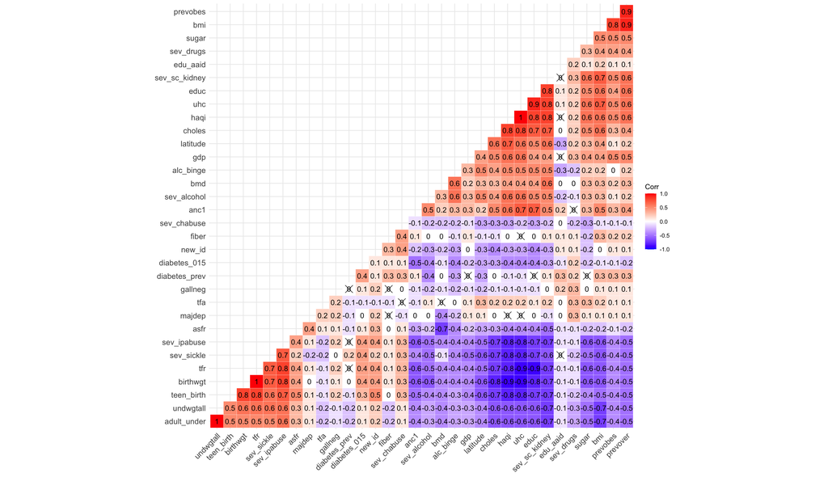

Aquellos que se identifican como más correlacionados con **alc_binge** son:

- latitute,
- choles,
- haqi,
- uhc,
- educ,
- sev_sc_kidney,
- bmd,
- sev_alcohol,
- diabetes_015
- asfr,
- sev_ipabuse,
- sev_sickle,
- tfr,
- birthwgt

Una vez que se descartan aquellos factores que están altamente correlacionados entre si:

```stata
corr alc_binge latitude choles haqi uhc educ sev_sc_kidney bmd sev_alcohol diabetes_015 asfr sev_ipabuse sev_sickle tfr birthwgt if `filter_country' & `filter_age',
```

```
(obs=16,320)

             | alc_bi~e latitude   choles     haqi      uhc     educ sev_sc~y
-------------+---------------------------------------------------------------
   alc_binge |   1.0000
    latitude |   0.5226   1.0000
      choles |   0.3916   0.6097   1.0000
        haqi |   0.5186   0.6682   0.8112   1.0000
         uhc |   0.4941   0.6337   0.7924   0.9904   1.0000
        educ |   0.4526   0.5306   0.6961   0.8374   0.8528   1.0000
sev_sc_kid~y |   0.5364   0.6454   0.7081   0.8049   0.8015   0.7514   1.0000
         bmd |   0.5900   0.3480   0.3219   0.4107   0.4039   0.4371   0.5814
 sev_alcohol |   0.6490   0.5205   0.4288   0.5808   0.5701   0.5288   0.5009
diabetes_015 |  -0.3530  -0.2630  -0.2789  -0.4396  -0.4495  -0.4318  -0.2876
        asfr |  -0.4027  -0.2823  -0.2716  -0.4103  -0.4156  -0.4458  -0.4533
 sev_ipabuse |  -0.4409  -0.5283  -0.7148  -0.7829  -0.7912  -0.7379  -0.6918
  sev_sickle |  -0.3508  -0.5719  -0.7268  -0.8357  -0.8117  -0.6566  -0.6037
         tfr |  -0.4332  -0.5484  -0.7322  -0.8473  -0.8599  -0.8653  -0.7396
    birthwgt |  -0.4226  -0.5952  -0.7616  -0.8707  -0.8760  -0.8382  -0.7385

             |      bmd sev_al~l diab~015     asfr sev_ip~e sev_si~e      tfr
-------------+---------------------------------------------------------------
         bmd |   1.0000
 sev_alcohol |   0.3060   1.0000
diabetes_015 |  -0.1344  -0.3881   1.0000
        asfr |  -0.7056  -0.2161   0.1450   1.0000
 sev_ipabuse |  -0.4115  -0.4815   0.3930   0.3785   1.0000
  sev_sickle |  -0.1412  -0.4913   0.3555   0.1831   0.6734   1.0000
         tfr |  -0.4271  -0.5417   0.4154   0.4400   0.8205   0.6696   1.0000
    birthwgt |  -0.4001  -0.5534   0.4112   0.4010   0.8091   0.6903   0.9553

             | birthwgt
-------------+---------
    birthwgt |   1.0000
```

Los siguientes factores se pueden considerar como variables relevantes y/o control para el fenómeno:

- bmd, choles, diabetes_015, sev_ipabuse, sev_alcohol

```stata
*asfr educ majdep physact prevobes prevover sev_act sev_transfat sev_kidney sev_sickle adult_under bmd alc_binge birthwgt choles bmi tfa undwgtall sev_sc_kidney diabetes_prev diabetes_015 latitude anc1 teen_birth edu_aaid fiber gallneg gdp haqi sugar tfr uhc sev_alcohol sev_drugs sev_chabuse sev_ipabuse age_yrs_med
```

# 2. Modelos

## 2.1 Exploración con OLS

**Nota:** La descripción de la base menciona que la variable **alc_alcohol** se refiere a *Age-standardized SEV for Impaired kidney function* pero no hace sentido con la documentación, aparentemente se trata de un error pues la variable descrita corresponde a **alc_binge_prop** (ver celdas B8:C8 del archivo de documentación *IHME_GBD_2019_COV_1980_2019_COV_DESCRIPTIONS_Y2020M10D15.csv*)

**M1.- Variables de estado de salud**

Modelo de alcoholismo como respuesta a índice de masa corporal y enfermedades crónico-degenerativas

```stata
*2.a
regress alc_binge bmd choles diabetes_015  if `filter_country' & `filter_age' , r
estimates store m1
```

```
Linear regression                               Number of obs     =     16,320
                                                F(3, 16316)       =    3821.74
                                                Prob > F          =     0.0000
                                                R-squared         =     0.4464
                                                Root MSE          =     .13345

------------------------------------------------------------------------------
             |               Robust
   alc_binge |      Coef.   Std. Err.      t    P>|t|     [95% Conf. Interval]
-------------+----------------------------------------------------------------
         bmd |   1.181689     .01367    86.44   0.000     1.154894    1.208484
      choles |   .0608257   .0024085    25.25   0.000     .0561047    .0655467
diabetes_015 |  -.1108829   .0038606   -28.72   0.000    -.1184501   -.1033156
       _cons |  -.7826367   .0114032   -68.63   0.000    -.8049882   -.7602852
------------------------------------------------------------------------------
```

**M2.- Variables de componente educativo**

Modelo de alcoholismo como respuesta de componente de acceso a la eduación

```stata
*2.b
regress alc_binge educ edu_aaid if `filter_country' & `filter_age' , r
estimates store m2
```

```
Linear regression                               Number of obs     =     16,320
                                                F(2, 16317)       =    3679.96
                                                Prob > F          =     0.0000
                                                R-squared         =     0.3036
                                                Root MSE          =     .14968

------------------------------------------------------------------------------
             |               Robust
   alc_binge |      Coef.   Std. Err.      t    P>|t|     [95% Conf. Interval]
-------------+----------------------------------------------------------------
        educ |   .0311165   .0003923    79.32   0.000     .0303476    .0318854
    edu_aaid |  -.0660275   .0012634   -52.26   0.000    -.0685038   -.0635511
       _cons |   .2541756   .0045767    55.54   0.000     .2452049    .2631464
------------------------------------------------------------------------------
```

**M3.- Variables de estado de salud + componente educativo**

Modelo de alcoholismo como respuesta de variables de salud + componente de acceso a la eduación

```stata
*2.c
regress alc_binge bmd choles diabetes_015 educ edu_aaid if `filter_country' & `filter_age' , r
estimates store m3
```

```
Linear regression                               Number of obs     =     16,320
                                                F(5, 16314)       =    3526.64
                                                Prob > F          =     0.0000
                                                R-squared         =     0.5240
                                                Root MSE          =     .12376

------------------------------------------------------------------------------
             |               Robust
   alc_binge |      Coef.   Std. Err.      t    P>|t|     [95% Conf. Interval]
-------------+----------------------------------------------------------------
         bmd |    1.10312   .0137903    79.99   0.000      1.07609    1.130151
      choles |   .0468413   .0028256    16.58   0.000     .0413028    .0523799
diabetes_015 |   -.108229   .0035501   -30.49   0.000    -.1151877   -.1012704
        educ |   .0057008    .000528    10.80   0.000     .0046659    .0067356
    edu_aaid |  -.0585477   .0011113   -52.68   0.000    -.0607261   -.0563694
       _cons |  -.5223493   .0123457   -42.31   0.000    -.5465482   -.4981504
------------------------------------------------------------------------------
```

**M4.- Modelo 3 mas componente de género**

```stata
*2.d
regress alc_binge bmd choles diabetes_015 educ edu_aaid sex_id if `filter_country' & `filter_age' , r
estimates store m4
```

```
Linear regression                               Number of obs     =     16,320
                                                F(6, 16313)       =    2958.54
                                                Prob > F          =     0.0000
                                                R-squared         =     0.5242
                                                Root MSE          =     .12373

------------------------------------------------------------------------------
             |               Robust
   alc_binge |      Coef.   Std. Err.      t    P>|t|     [95% Conf. Interval]
-------------+----------------------------------------------------------------
         bmd |   1.035026   .0282703    36.61   0.000     .9796134    1.090439
      choles |   .0497076   .0030536    16.28   0.000     .0437221     .055693
diabetes_015 |  -.1073612   .0035688   -30.08   0.000    -.1143563    -.100366
        educ |   .0061735   .0005559    11.10   0.000     .0050838    .0072632
    edu_aaid |  -.0589238   .0011065   -53.25   0.000    -.0610927    -.056755
      sex_id |  -.0108764   .0040802    -2.67   0.008    -.0188741   -.0028788
       _cons |  -.4648428   .0237754   -19.55   0.000    -.5114451   -.4182404
------------------------------------------------------------------------------
```

Se observa una posible dependencia no lineal entre la variable choles y alc_binge, intentemos introducir un efecto no lineal para mejorar el ajuste

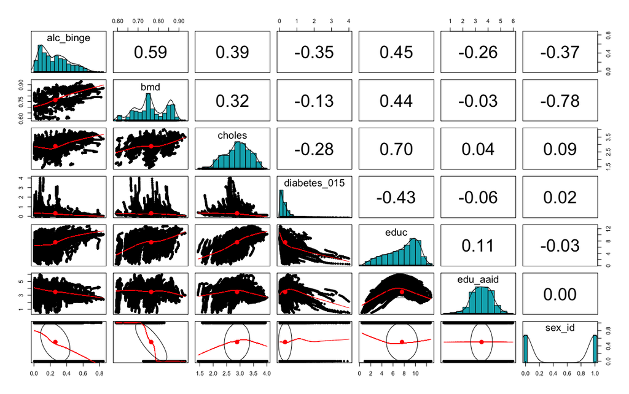

```stata
* 2e Modelo 4, mas componente no lineal
gen choles3 = choles^3
regress alc_binge bmd choles choles3 diabetes_015 educ edu_aaid sex_id if `filter_country' & `filter_age' , r
estimates store m5
```

```
Linear regression                               Number of obs     =     16,320
                                                F(7, 16312)       =    2656.27
                                                Prob > F          =     0.0000
                                                R-squared         =     0.5373
                                                Root MSE          =     .12203

------------------------------------------------------------------------------
             |               Robust
   alc_binge |      Coef.   Std. Err.      t    P>|t|     [95% Conf. Interval]
-------------+----------------------------------------------------------------
         bmd |   1.117625   .0285482    39.15   0.000     1.061668    1.173583
      choles |  -.1884609    .011312   -16.66   0.000    -.2106335   -.1662882
     choles3 |   .0096875   .0004602    21.05   0.000     .0087855    .0105895
diabetes_015 |  -.0944059   .0034408   -27.44   0.000    -.1011503   -.0876615
        educ |   .0062623   .0005362    11.68   0.000     .0052113    .0073133
    edu_aaid |  -.0509819   .0011452   -44.52   0.000    -.0532266   -.0487372
      sex_id |   .0038024   .0041077     0.93   0.355     -.004249    .0118539
       _cons |  -.1467432   .0284805    -5.15   0.000    -.2025681   -.0909184
------------------------------------------------------------------------------
```

**Nota:** El R cuadrada aumenta, pero deja de ser significativo el género, lo cual es contrario a lo observado en el análsis exploratorio. Posiblemente se asocien efectos no apropiados a la nueva variable

**Resumen**

```stata
estimates table m1 m2 m3 m4 m5, star stats(N r2 r2_a)
```

```
------------------------------------------------------------------------------
    Variable |      m1              m2              m3              m4
-------------+----------------------------------------------------------------
         bmd |   1.181689***                    1.1031201***    1.0350262***
      choles |  .06082568***                    .04684133***    .04970756***
diabetes_015 | -.11088285***                   -.10822904***   -.10736118***
        educ |                  .03111652***    .00570077***    .00617353***
    edu_aaid |                 -.06602747***   -.05854773***   -.05892384***
      sex_id |                                                 -.01087644**
     choles3 |
       _cons | -.78263673***    .25417562***   -.52234928***   -.46484276***
-------------+----------------------------------------------------------------
           N |      16320           16320           16320           16320
          r2 |  .44643899       .30360297       .52399022       .52420578
        r2_a |  .44633721       .30351761       .52384433       .52403078
------------------------------------------------------------------------------
                                      legend: * p<0.05; ** p<0.01; *** p<0.001


------------------------------
    Variable |      m5
-------------+----------------
         bmd |  1.1176255***
      choles | -.18846085***
diabetes_015 |  -.0944059***
        educ |  .00626229***
    edu_aaid |  -.0509819***
      sex_id |  .00380241
     choles3 |  .00968747***
       _cons | -.14674321***
-------------+----------------
           N |      16320
          r2 |  .53727918
        r2_a |  .53708061
------------------------------
legend: * p<0.05; ** p<0.01; *** p<0.001
```

Algunos puntos relevantes a notar:

- En todos los casos se obtienes valores de R cuadrada menoes a 55% de varianza explicada,
- Aunque casi todos los coeficientes parecen ser significativos, los signos no parecen congruentes con la naturaleza del fenómeno.
- La existencia de variables omitidas, puede derivar en que al realizar el ajuste el modelo ajuste los coeficientes con sesgo, de manera que aparentemente explican el fenómeno sin toda la información que lo explica.
- No se han contado efectos fijos de tiempo o espacio, que podrían ayudar a explicar la variabilidad del fenómeno en términos espaciales (propios de la indrosincracia de los lugares) o eventos con incidencia en años particular que propociaron un mayor consumo de alcohol.

## 2.2 Modelos con efectos fijos

```stata
* 2.f
xtset location_id
xtreg alc_binge bmd choles diabetes_015 if `filter_age' & `filter_country', vce(cluster location_id)
estimates store m6
```

```
       panel variable:  location_id (balanced)


Random-effects GLS regression                   Number of obs     =     16,320
Group variable: location_id                     Number of groups  =        204

R-sq:                                           Obs per group:
     within  = 0.5820                                         min =         80
     between = 0.3309                                         avg =       80.0
     overall = 0.3143                                         max =         80

                                                Wald chi2(3)      =     364.49
corr(u_i, X)   = 0 (assumed)                    Prob > chi2       =     0.0000

                          (Std. Err. adjusted for 204 clusters in location_id)
------------------------------------------------------------------------------
             |               Robust
   alc_binge |      Coef.   Std. Err.      z    P>|z|     [95% Conf. Interval]
-------------+----------------------------------------------------------------
         bmd |   .9986981   .0567002    17.61   0.000     .8875677    1.109828
      choles |  -.0292505   .0191716    -1.53   0.127    -.0668263    .0083252
diabetes_015 |  -.0123608   .0099451    -1.24   0.214    -.0318528    .0071312
       _cons |  -.4140806   .0671057    -6.17   0.000    -.5456053   -.2825558
-------------+----------------------------------------------------------------
     sigma_u |  .11866667
     sigma_e |  .05509576
         rho |  .82266253   (fraction of variance due to u_i)
------------------------------------------------------------------------------
```

**M7.- Variables de componente educativo + Efectos fijos**

```stata
* M7
xtset location_id
xtreg alc_binge educ edu_aaid if `filter_country' & `filter_age', fe vce(cluster location_id)
estimates store m7
```

```
       panel variable:  location_id (balanced)


Fixed-effects (within) regression               Number of obs     =     16,320
Group variable: location_id                     Number of groups  =        204

R-sq:                                           Obs per group:
     within  = 0.0006                                         min =         80
     between = 0.4494                                         avg =       80.0
     overall = 0.2897                                         max =         80

                                                F(2,203)          =       4.14
corr(u_i, Xb)  = 0.5915                         Prob > F          =     0.0173

                          (Std. Err. adjusted for 204 clusters in location_id)
------------------------------------------------------------------------------
             |               Robust
   alc_binge |      Coef.   Std. Err.      t    P>|t|     [95% Conf. Interval]
-------------+----------------------------------------------------------------
        educ |   .0012655    .001278     0.99   0.323    -.0012544    .0037855
    edu_aaid |  -.0040092   .0017988    -2.23   0.027    -.0075559   -.0004625
       _cons |   .2649421   .0053742    49.30   0.000     .2543456    .2755386
-------------+----------------------------------------------------------------
     sigma_u |  .15568015
     sigma_e |  .08519681
         rho |  .76953354   (fraction of variance due to u_i)
------------------------------------------------------------------------------
```

**M8.- Variables de estado de salud + componente educativo + Efectos fijos**

```stata
xtset location_id
xtreg alc_binge bmd choles diabetes_015 educ edu_aaid if `filter_country' & `filter_age', fe vce(cluster location_id)
estimates store m8
```

```
       panel variable:  location_id (balanced)


Fixed-effects (within) regression               Number of obs     =     16,320
Group variable: location_id                     Number of groups  =        204

R-sq:                                           Obs per group:
     within  = 0.5916                                         min =         80
     between = 0.3272                                         avg =       80.0
     overall = 0.3017                                         max =         80

                                                F(5,203)          =      81.86
corr(u_i, Xb)  = 0.1817                         Prob > F          =     0.0000

                          (Std. Err. adjusted for 204 clusters in location_id)
------------------------------------------------------------------------------
             |               Robust
   alc_binge |      Coef.   Std. Err.      t    P>|t|     [95% Conf. Interval]
-------------+----------------------------------------------------------------
         bmd |   1.024242   .0538149    19.03   0.000     .9181339    1.130349
      choles |  -.0091407   .0232532    -0.39   0.695    -.0549895    .0367082
diabetes_015 |  -.0377221   .0144148    -2.62   0.010    -.0661441   -.0093002
        educ |  -.0080601   .0018368    -4.39   0.000    -.0116818   -.0044384
    edu_aaid |  -.0015191   .0018906    -0.80   0.423    -.0052468    .0022087
       _cons |  -.4170297   .0706445    -5.90   0.000    -.5563207   -.2777386
-------------+----------------------------------------------------------------
     sigma_u |  .14246832
     sigma_e |  .05446644
         rho |  .87248039   (fraction of variance due to u_i)
------------------------------------------------------------------------------
```

**M9.- Modelo 3 mas componente de género + Efectos fijos**

```stata
xtset location_id
xtreg alc_binge bmd choles diabetes_015 educ edu_aaid sex_id if `filter_country' & `filter_age', fe vce(cluster location_id)
estimates store m9
```

```
       panel variable:  location_id (balanced)


Fixed-effects (within) regression               Number of obs     =     16,320
Group variable: location_id                     Number of groups  =        204

R-sq:                                           Obs per group:
     within  = 0.6304                                         min =         80
     between = 0.2169                                         avg =       80.0
     overall = 0.2101                                         max =         80

                                                F(6,203)          =      77.80
corr(u_i, Xb)  = 0.0869                         Prob > F          =     0.0000

                          (Std. Err. adjusted for 204 clusters in location_id)
------------------------------------------------------------------------------
             |               Robust
   alc_binge |      Coef.   Std. Err.      t    P>|t|     [95% Conf. Interval]
-------------+----------------------------------------------------------------
         bmd |   .2655267   .1338757     1.98   0.049     .0015614     .529492
      choles |   .0170232   .0233669     0.73   0.467    -.0290499    .0630962
diabetes_015 |  -.0401047   .0125868    -3.19   0.002    -.0649223   -.0152871
        educ |  -.0071176   .0017417    -4.09   0.000    -.0105518   -.0036834
    edu_aaid |  -.0033513   .0019249    -1.74   0.083    -.0071467    .0004441
      sex_id |  -.1036434   .0174036    -5.96   0.000    -.1379583   -.0693284
       _cons |   .2425767   .1244755     1.95   0.053    -.0028541    .4880074
-------------+----------------------------------------------------------------
     sigma_u |  .15179826
     sigma_e |   .0518184
         rho |  .89563273   (fraction of variance due to u_i)
------------------------------------------------------------------------------
```

**M10.- Modelo 5 + Efecto no lineal de variable choles + Efectos fijos**

```stata
drop choles3
```

```stata
gen choles3 = choles^3
xtreg alc_binge bmd choles choles3 diabetes_015 educ edu_aaid sex_id if `filter_country' & `filter_age', fe vce(cluster location_id)
estimates store m10
```

```
Fixed-effects (within) regression               Number of obs     =     16,320
Group variable: location_id                     Number of groups  =        204

R-sq:                                           Obs per group:
     within  = 0.6496                                         min =         80
     between = 0.0337                                         avg =       80.0
     overall = 0.1691                                         max =         80

                                                F(7,203)          =      69.91
corr(u_i, Xb)  = -0.0284                        Prob > F          =     0.0000

                          (Std. Err. adjusted for 204 clusters in location_id)
------------------------------------------------------------------------------
             |               Robust
   alc_binge |      Coef.   Std. Err.      t    P>|t|     [95% Conf. Interval]
-------------+----------------------------------------------------------------
         bmd |   .1693115   .1435726     1.18   0.240    -.1137733    .4523963
      choles |   .3911255   .1035948     3.78   0.000     .1868657    .5953852
     choles3 |  -.0130629   .0031767    -4.11   0.000    -.0193264   -.0067993
diabetes_015 |  -.0359539   .0122303    -2.94   0.004    -.0600686   -.0118393
        educ |  -.0095221   .0020562    -4.63   0.000    -.0135763    -.005468
    edu_aaid |  -.0064067   .0023478    -2.73   0.007    -.0110359   -.0017775
      sex_id |  -.1270489   .0202964    -6.26   0.000    -.1670676   -.0870301
       _cons |  -.3616633   .1888146    -1.92   0.057    -.7339526     .010626
-------------+----------------------------------------------------------------
     sigma_u |  .15604816
     sigma_e |  .05045627
         rho |  .90534826   (fraction of variance due to u_i)
------------------------------------------------------------------------------
```

```stata
estimates table m1 m2 m3 m4 m5 m6 m7 m8 m9 m10, star stats(N r2 r2_a sigma_u sigma_e rho)
```

[output not shown]

[output cut: 9 more lines]

```
diabetes_015 |  -.0401047**    -.03595393**
        educ | -.00711761***   -.00952214***
    edu_aaid | -.00335128      -.00640667**
      sex_id | -.10364337***   -.12704887***
     choles3 |                 -.01306286***
       _cons |  .24257669      -.36166328
-------------+--------------------------------
           N |      16320           16320
          r2 |  .63036857       .64956765
        r2_a |  .63023262       .64941726
     sigma_u |  .15179826       .15604816
     sigma_e |   .0518184       .05045627
         rho |  .89563273       .90534826
----------------------------------------------
      legend: * p<0.05; ** p<0.01; *** p<0.001
```

**Nota**

- Se propone al modelo 10 como modelo ganador, porque:
  - Incluyen los efectos fijos de la ubicacón fisica de los países.
  - Su R2 es mayor,
  - Posee el mayor la fracción de la varianza debida a ui (efecto individual de los paises)
  - Casi todos los coeficientes son significativos,
  - Los signos hacen sentido con la logica del problema,